# STOR 767 Spring 2019 Hw1: Computational Part

## List

List is a more flexible container of “data” that permits inhomogeneous types. It’s useful if you would like to encapsulate a bunch of components in an object. The `list` function explicitly specifies a list and the combining function `c` is still applicable. For example,

```r
x <- list( num   = 1:4,                # "num =" specifies the name of the first component
           chac  = "hello world!",
           logic = c(TRUE,FALSE),
           nu    = NULL,
           mat   = matrix(4:1, 2, 2) ) # to the left of "=" specifies the component name
y <- list( 1234,
           "world" )
c(x, y)
```

To extract the components in a list, one should use double bracket `[[ ]]` instead of a single bracket. If you’ve already specified the component names in a list, then the component names can be placed into the bracket directly. For example, `x[["logic"]]` accesses the third component of `x`. A more handful alternative is `x$logic`.

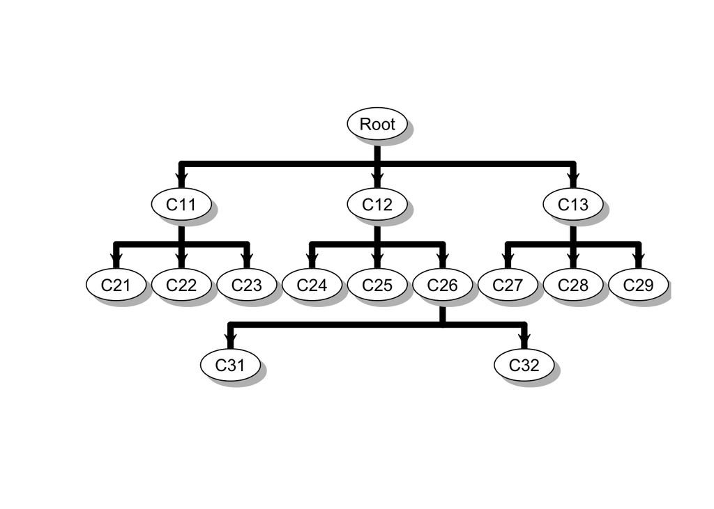

```r
C11 <- list( C21 = "C21",
             C22 = "C22",
             C23 = "C23")
C26 <- list( C31 = "C31",
             C32 = "C32")
C13 <- list( C27 = "C27",
             C28 = "C28",
             C29 = "C29")
C12 <- list( C24 = "C24",
             C25 = "C25",
             C26 = C26)
Root <- list( C11 = C11,
              C12 = C12,
              C13 = C13)

# subtree rooted at C12
Root[[2]]
Root$C12

# subtree (leaf) rooted at C24
Root[[c(2,1)]]
Root$C12$C24

# subtree rooted at C26
Root[[c(2,3)]]
Root$C12$C26

# subtree (leaf) rooted at C31
Root[[c(2,3,1)]]
Root$C12$C26$C31
```

## Date Frame

Inheriting from matrix and list, data.frame is a container general enough for us to study a dataset. It permits inhomogeneous data types across columns (components in a list) but forces the components of the list to be vectors of homogeneous length (so as to be columns in a matrix). For example, the following creates a score table of 3 students.

```r
students <- data.frame( id      = c("001", "002", "003"), # ids are characters
                        score_A = c(95, 97, 90),          # scores are numerics
                        score_B = c(80, 75, 84))
students
```

To access the score_A of student $003$, one can follow the manner in a matrix: `students[3,2]`, or that in a list: `students[[[2]][3]`, `students[["score_A"]][3]` or `students$score_A[3]`. One can also create a matrix or a legitimate list first and then convert it into a data.frame as follows.

```r
scores <- matrix(c(95, 97, 90, 80, 75, 84), 3, 2)
scores <- data.frame(scores)
colnames(scores) <- c("score_A", "score_B")
id <- c("001", "002", "003")
students1 <- cbind(id, scores)
students2 <- data.frame( list( id      = c("001", "002", "003"),
                               score_A = c(95, 97, 90),
                               score_B = c(80, 75, 84))
                         )
```